# It’s About Time: Using Survival Analysis to Gain Time-Based People Insights

Behailu Bekera

April 4, 2019

# Part 0: House Keeping

```r
#Clear your workspace
#rm(list = ls())

#set working directory to where the data resides
setwd("C:/Users/bbekera/Desktop/SIOP Master Tutorial")
load(file = "Data/Survival.RData")
```

```r
#Load required packages
library(survival)
library(dplyr)
library(ranger)
library(ggplot2)
library(survminer)
library(pec)
```

```r
#Load data
data <- merge_data
```

Columns:

applicant_id  
term_reason_text  
application_date  
hire_date  
term_date  
emp1_start_date  
emp1_end_date  
new_job_title_hire  
times_available  
times_not_available  
highest_education  
overall_percentile  
storelocation  
home_state_province  
home_city

# Part 1: Data preparation

```r
#Remove temporary positions and reduction in force
data <- subset(data, term_reason_text != "Invol-Elimination of Position")
data <- subset(data, term_reason_text != "Invol-End of Temporary Pos")
data <- subset(data, term_reason_text != "Invol - Location Closure")
```

```r
#Date variables to format into "%m/%d/%Y" format
datvar<-c("application_date","hire_date","term_date","emp1_start_date","emp1_end_date","emp2_start_date","emp2_end_date","emp3_start_date","emp3_end_date","emp4_start_date","emp4_end_date","edu1_start_date", "edu2_start_date","edu3_start_date","edu4_start_date")

#Format date variables
data[,c(which(colnames(data) %in% datvar))] <- lapply(data[c(which(colnames(data) %in% datvar))],function(x) as.Date(x,format="%m/%d/%Y"))
```

```r
#Calculate best guess of data extract date as the maximum termination date reported
#this is the right censor date for the survival analysis
extract_date <- max(data$term_date, na.rm=T)

#Calculate raw tenure variables
data$tenure_raw <- as.numeric(data$term_date - data$hire_date)

#counts how many cases have a hire_date after the term_date
sum(data$hire_date>data$term_date, na.rm=T)
```

```
## [1] 0
```

```r
#Flag for excluding negative values for tenure
data$exclude<-ifelse(data$hire_date>data$term_date,1,0)
```

```r
#Used to substitute tenure value when term_date is NA
data$since_hire <- extract_date - data$hire_date

#Create clean continuous tenure variable
#This is the time to event
data$tenure_cont <- NA

for(i in 1:nrow(data)){
  #minimum of raw tenure or days since hired; only fills in days since hire if the raw is NA
  data$tenure_cont[i] <- min(c(data$tenure_raw[i],data$since_hire[i]), na.rm=T)
}

#Overwrite NA for nonsense values
data$tenure_cont[data$exclude == 1] <- NA

#Tenure summary stats
summary(data$tenure_cont)
```

```
##    Min. 1st Qu.  Median    Mean 3rd Qu.    Max.
##     1.0    49.0   106.0   187.6   253.0   982.0
```

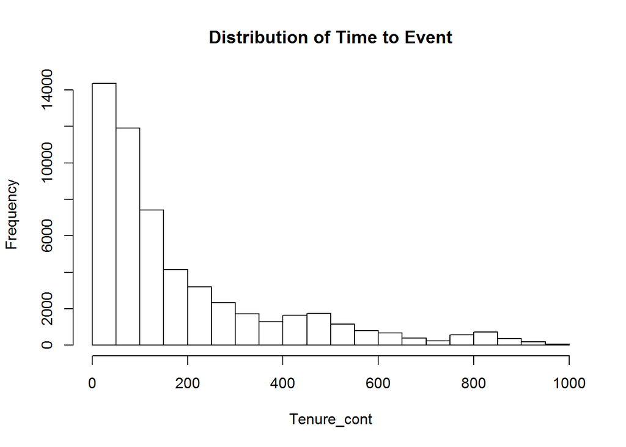

```r
hist(data$tenure_cont, main = "Distribution of Time to Event", xlab = "Tenure_cont")
```

```r
#create attrition variable to indicate whether the event happended during the study period
#sum(is.na(data$term_date))
data$attrited <- ifelse(is.na(data$term_date) == TRUE,0,1)

#Number of attrites and those stayed
table(data$attrited)
```

```
##
##     0     1
## 15819 39012
```

```r
#Tenure distribution among stayers
summary(data$tenure_cont[data$attrited == 0])
```

```
##    Min. 1st Qu.  Median    Mean 3rd Qu.    Max.
##     4.0    81.0   178.0   294.6   477.0   982.0
```

```r
#Tenure distribution among stayers
summary(data$tenure_cont[data$attrited == 1])
```

```
##    Min. 1st Qu.  Median    Mean 3rd Qu.    Max.
##     1.0    39.0    89.0   144.2   196.0   940.0
```

# Part 2: Survival Curve Analysis

```r
#Retain data for those currently with a Sales Associate job title
sa_data <- subset(data, new_job_title_hire == "Sales Associate")
```

```r
#Create a survival object that is used as a response variable in a model formula.
sa_surv <- Surv(sa_data$tenure_cont, sa_data$attrited)

#Right-censored times to event (where attrition wasn't observed yet) have a "+" sign
#Printing out the first 30
head(sa_surv,30)
```

```
##  [1]  53+  21  249   42   74  572+ 147   41+  84  568  150  151  196+ 219
## [15]  25  565+ 469+ 313   13   57  308  147+ 162   37+ 118  213  182  126
## [29] 586   33+
```

```r
#Printing out tenure values for the first 30
sa_data$tenure_cont[0:30]
```

```
##  [1]  53  21 249  42  74 572 147  41  84 568 150 151 196 219  25 565 469
## [18] 313  13  57 308 147 162  37 118 213 182 126 586  33
```

The formula sa_surv ~ 1 instructs the survfit() function to fit a model with intercept only,  
and produces the Kaplan-Meier survival curve estimate.

```r
sa_km_fit <- survfit(sa_surv ~ 1)
```

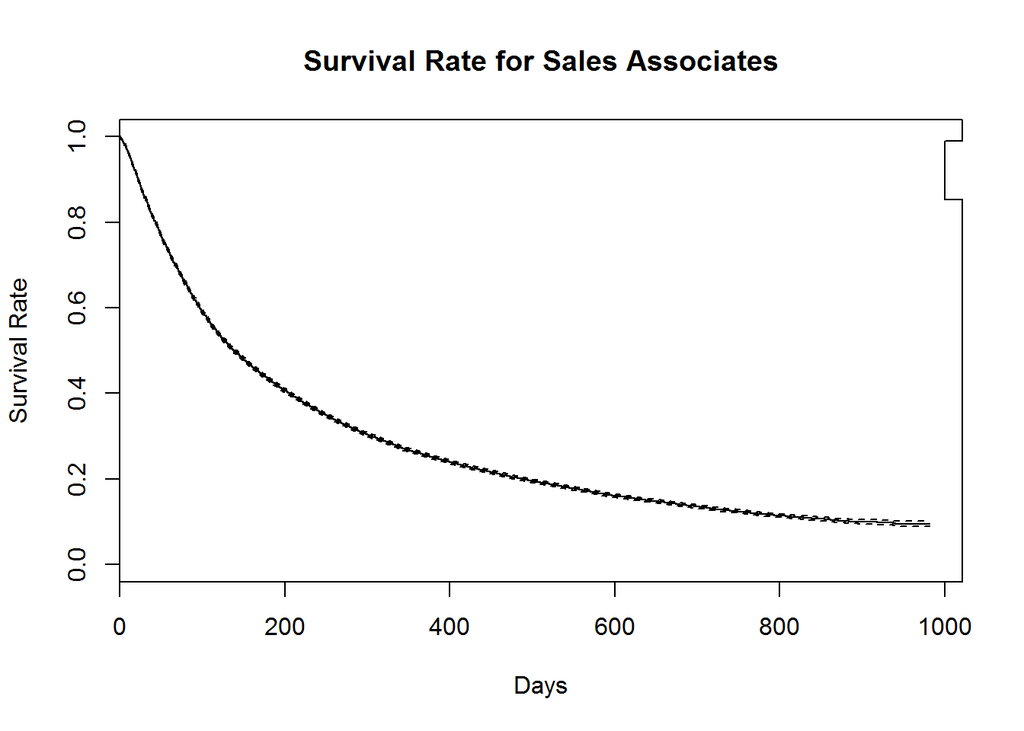

[figure not shown]

```r
#Option 1 ploting KM curve
plot(sa_km_fit,
     main = 'Survival Rate for Sales Associates',ylab = "Survival Rate", xlab = "Days")
legend(1000, 0.99, legend = c('K-M survival estimate'), lty = 1:2)
```

To get the number of days after which survival Rate reaches a certain percentage (e.g. 75%, 50%, 25%, 62%, 43%, 26%)

```r
#head(summary(sa_km_fit))

Time_and_prob=cbind.data.frame(sa_km_fit$time,sa_km_fit$surv)
colnames(Time_and_prob)<-c("time", "surv")

Time_and_prob$surv= round(Time_and_prob$surv, 2)

Probs= c(0.75, 0.5, 0.25, 0.62, 0.43, 0.26)

for (i in 1: length(Probs)){
  print (paste("Survival Rate reaches ", Probs[i], "%", " on day ", max(Time_and_prob$time[Time_and_prob$surv==Probs[i]]),sep = ""))
}
```

```
## [1] "Survival Rate reaches 0.75% on day 55"
## [1] "Survival Rate reaches 0.5% on day 141"
## [1] "Survival Rate reaches 0.25% on day 389"
## [1] "Survival Rate reaches 0.62% on day 91"
## [1] "Survival Rate reaches 0.43% on day 185"
## [1] "Survival Rate reaches 0.26% on day 371"
```

## Part 3: Feature Engineering

Creating features associated with availability:

```r
#See some of the raw times available values
head(data$times_available,1)
```

```
## [1] Monday Mornings;Monday Afternoons;Monday Evenings;Tuesday Mornings;Tuesday Afternoons;Tuesday Evenings;Wednesday Mornings;Wednesday Afternoons;Thursday Mornings;Thursday Afternoons;Thursday Evenings;Friday Mornings;Friday Afternoons;Friday Evenings;Saturday Mornings;Saturday Afternoons;Saturd…
## 40783 Levels:  ... Wednesday Mornings;Wednesday Evenings;Thursday Mornings;Thursday Evenings;Friday Evenings;Saturday Mornings;Sunday Mornings;Sunday Afternoons
```

```r
#Initialize new times available features
data$time_slots_available <- 0
data$weekends_only <- NA
data$weekdays_only <- NA
data$both <- NA

#Populate these times available features with values
for (i in 1:nrow(data)){
  temp <- as.character(data$times_available[i])

  #Number of time slots available
  data$time_slots_available[i] <- length(unlist(strsplit(temp,";")))

  #1 if available weekends ONLY, 0 otherwise even if no time slots mentioned at all
  data$weekends_only[i] <- ifelse(grepl("(Sat|Sun)",temp) == TRUE & grepl("(Mon|Tues|Wed|Thurs|Fri)",temp) == FALSE,1,0)

  #1 if available weekdays ONLY, 0 otherwise even if no time slots mentioned at all
  data$weekdays_only[i] <- ifelse(grepl("(Sat|Sun)",temp) == FALSE & grepl("(Mon|Tues|Wed|Thurs|Fri)",temp) == TRUE,1,0)

  #1 if available both weekdays and weekends, 0 otherwise even if no time slots mentioned at all
  data$both[i] <- ifelse(grepl("(Sat|Sun)",temp) == TRUE & grepl("(Mon|Tues|Wed|Thurs|Fri)",temp) == TRUE,1,0)
}

#Fill in NA if no time slots selected, that
data$weekends_only[data$time_slots_available == 0] <- NA # Now, data$weekends_only==1 => weekends_only and 0 means weekdays, NA mean no time slots given
data$weekdays_only[data$time_slots_available == 0] <- NA #Now, data$weekdays_only==1 => weekdays_only and 0 means weekends, NA mean no time slots given
data$both[data$time_slots_available == 0] <- NA # Now, data$both==1 => mentioned both weekends and weekdays, NA means neither(no time slots given)


#table(data$time_slots_available) #Number of time slots applicant is available for
#table(data$weekends_only)
#table(data$weekdays_only)
#table(data$both)
```

Creating Education Level features:

```r
#Highest education values
table(data$highest_education)
```

```
##
##                                   Associates's Degree
##                         45                       1420
##    Associates&#39;s Degree         Associatess Degree
##                       6465                        614
##          Bachelor's Degree      Bachelor&#39;s Degree
##                       1913                       8183
##           Bachelors Degree            College Diploma
##                        822                        957
##            Doctoral Degree High School or Equivalency
##                        181                      31843
##            Master's Degree        Master&#39;s Degree
##                        437                       1769
##             Masters Degree                       NULL
##                        182                          0
```

```r
#Renaming and standardizing highest edudaction data
data$highest_education[data$highest_education == "Associates&#39;s Degree"] <- "Associates's Degree"
data$highest_education[data$highest_education == "Associatess Degree"] <- "Associates's Degree"
data$highest_education[data$highest_education == "Bachelor&#39;s Degree"] <- "Bachelor's Degree"
data$highest_education[data$highest_education == "Bachelors Degree"] <- "Bachelor's Degree"
data$highest_education[data$highest_education == "Master&#39;s Degree"] <- "Master's Degree"
data$highest_education[data$highest_education == "Masters Degree"] <- "Master's Degree"
data$highest_education <- factor(data$highest_education)
```

```r
#Creating binary versions of highest education features
data$high_school <- ifelse(data$highest_education == "High School or Equivalency",1,0)
data$associates <- ifelse(data$highest_education == "Associates's Degree",1,0)
data$bachelor <- ifelse(data$highest_education == "Bachelor's Degree",1,0)
data$masters_plus <- ifelse(data$highest_education == "Master's Degree" | data$highest_education == "Doctoral Degree",1,0)

data$college <- ifelse(data$highest_education == "Associates's Degree"|
                         data$highest_education == "Bachelor's Degree"|
                         data$highest_education == "College Diploma"|
                         data$highest_education == "Doctoral Degree"|
                         data$highest_education == "Master's Degree",1,0)
```

```r
#Number of applicants vs non
#table(data$high_school)
#table(data$associates)
#table(data$bachelor)
#table(data$masters_plus)
#table(data$college)
```

## Part 4: Feature-specific survival curve analysis

```r
#Subset sales associate data beause that is the role this model is going to be built for.
sa_data <- subset(data, new_job_title_hire == "Sales Associate")
sl_data <- subset(data, new_job_title_hire == "Sales Leader")
```

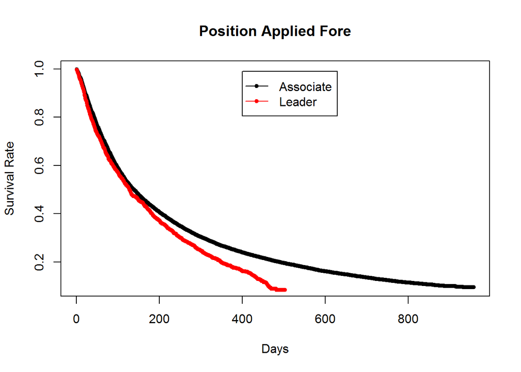

```r
#Overlay KM Plots based on job applied for

#Applied to Sales Associate role
sa_data_sa_app <- subset(sa_data, new_job_group_application == "Retail Salespersons")

#Applied to Sales Leader role
sa_data_sl_app <- subset(sa_data, new_job_group_application == "First-Line Supervisors of Retail Sales Workers")

#Create survival object for both types of applicants
sa_surv_sa_app <- Surv(sa_data_sa_app$tenure_cont, sa_data_sa_app$attrited)
sa_sa_app_km_fit <- survfit(sa_surv_sa_app ~ 1)

sa_surv_sl_app <- Surv(sa_data_sl_app$tenure_cont, sa_data_sl_app$attrited)
sa_sl_app_km_fit <- survfit(sa_surv_sl_app ~ 1)

plot(sa_sa_app_km_fit$surv,
     main = 'Position Applied Fore', ylab = "Survival Rate", xlab = "Days",lty = 2, pch = 20)
points(sa_sl_app_km_fit$surv, col = "red",lty = 2, pch = 20)
legend(400, 0.99, legend = c('Associate','Leader'),
                        col = c("black","red"), pch = c(20,20),
                        lwd = c(1,1))
```

Rehire or not:

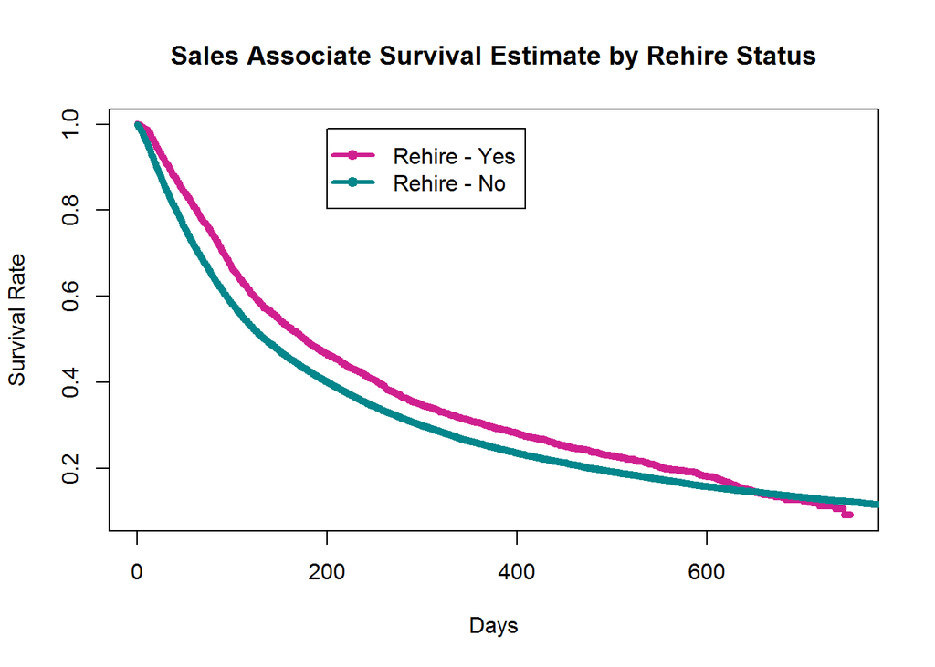

```r
wdata <- subset(sa_data, rehire == 1)
sa_surv_rehire_yes <- Surv(wdata$tenure_cont, wdata$attrited)
sa_rehire_yes_km_fit <- survfit(sa_surv_rehire_yes ~ 1)

wdata <- subset(sa_data, rehire == 0)
sa_surv_rehire_no <- Surv(wdata$tenure_cont, wdata$attrited)
sa_rehire_no_km_fit <- survfit(sa_surv_rehire_no ~ 1)


plot(sa_rehire_yes_km_fit$surv,
     main = 'Sales Associate Survival Estimate by Rehire Status',
     ylab = "Survival Rate", xlab = "Days",
     lty = 2, pch = 20, col = "violetred")
points(sa_rehire_no_km_fit$surv, col = "turquoise4",lty = 2, pch = 20)
legend(200, 0.99, legend = c('Rehire - Yes','Rehire - No'),
       col = c("violetred","turquoise4"),
       lwd = c(3,3), pch = 20)
```

Highest education:

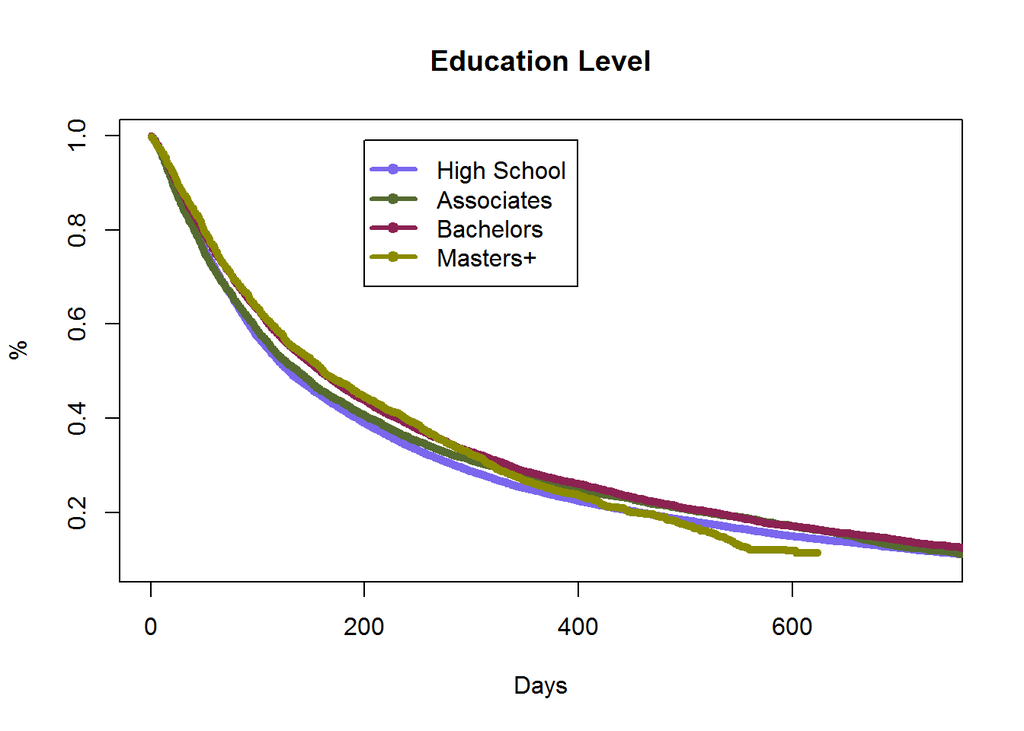

```r
wdata <- subset(sa_data, high_school == 1)
sa_surv_hs <- Surv(wdata$tenure_cont, wdata$attrited)
sa_hs_km_fit <- survfit(sa_surv_hs ~ 1)

wdata <- subset(sa_data, associates == 1)
sa_surv_associates <- Surv(wdata$tenure_cont, wdata$attrited)
sa_associates_km_fit <- survfit(sa_surv_associates ~ 1)

wdata <- subset(sa_data, bachelor == 1)
sa_surv_bachelor <- Surv(wdata$tenure_cont, wdata$attrited)
sa_bachelor_km_fit <- survfit(sa_surv_bachelor ~ 1)

wdata <- subset(sa_data, masters_plus == 1)
sa_surv_masters_plus <- Surv(wdata$tenure_cont, wdata$attrited)
sa_masters_plus_km_fit <- survfit(sa_surv_masters_plus ~ 1)

wdata <- subset(sa_data, college == 1)
sa_surv_college_yes <- Surv(wdata$tenure_cont, wdata$attrited)
sa_college_yes_km_fit <- survfit(sa_surv_college_yes ~ 1)

wdata <- subset(sa_data, college == 0)
sa_surv_college_no <- Surv(wdata$tenure_cont, wdata$attrited)
sa_college_no_km_fit <- survfit(sa_surv_college_no ~ 1)


plot(sa_hs_km_fit$surv,
     main = 'Education Level',
     ylab = "%", xlab = "Days",
     lty = 2, pch = 20, col = "slateblue2", xlim = c(0,730))
points(sa_associates_km_fit$surv, col = "darkolivegreen",lty = 2, pch = 20)
points(sa_bachelor_km_fit$surv, col = "violetred4",lty = 2, pch = 20)
points(sa_masters_plus_km_fit$surv, col = "yellow4",lty = 2, pch = 20)
legend(200, 0.99, legend = c('High School','Associates','Bachelors','Masters+'),
       col = c("slateblue2","darkolivegreen",'violetred4','yellow4'),
       lwd = c(3,3), pch = 20)
```

Survival by Hours Available:

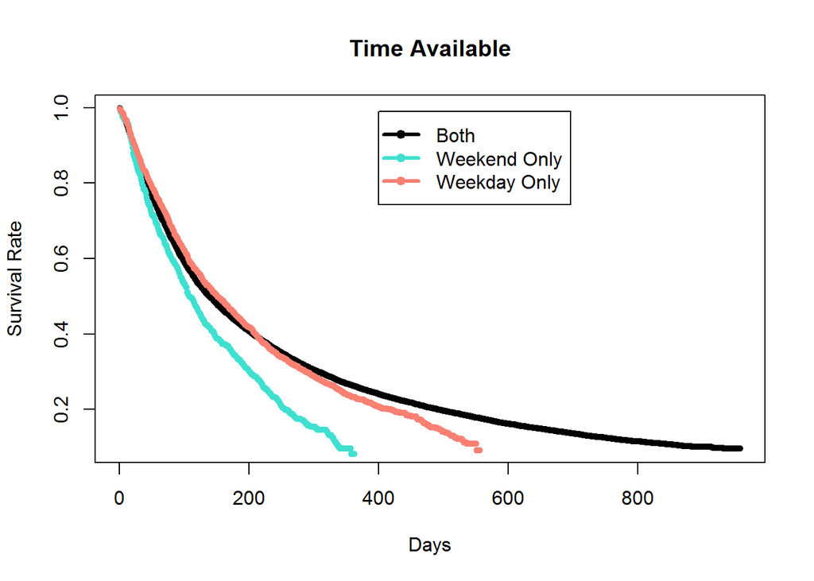

```r
wdata <- subset(sa_data, weekends_only == 1)
sa_surv_weekend <- Surv(wdata$tenure_cont, wdata$attrited)
sa_weekend_km_fit <- survfit(sa_surv_weekend ~ 1)


wdata <- subset(sa_data, weekdays_only == 1)
sa_surv_weekday <- Surv(wdata$tenure_cont, wdata$attrited)
sa_weekday_km_fit <- survfit(sa_surv_weekday ~ 1)


wdata <- subset(sa_data, both == 1)
sa_surv_both <- Surv(wdata$tenure_cont, wdata$attrited)
sa_both_km_fit <- survfit(sa_surv_both ~ 1)



plot(sa_both_km_fit$surv,
     main = 'Time Available',
     ylab = "Survival Rate", xlab = "Days",
     lty = 2, pch = 20)
points(sa_weekend_km_fit$surv, col = "turquoise",lty = 2, pch = 20)
points(sa_weekday_km_fit$surv, col = "salmon",lty = 2, pch = 20)

legend(400, 0.99, legend = c('Both','Weekend Only','Weekday Only'),
       col = c("black","turquoise","salmon"),
       lwd = c(3,3,3), pch = 20)
```

Sales Associate Survival Estimate by Assessment Score Group:

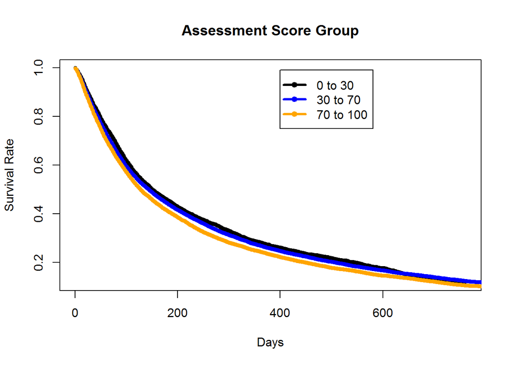

```r
#check for NA values
#sum(is.na(sa_data_sa_app$overall_percentile))

#Create catagorical assessment score feature
sa_data_sa_app$assessment_group <- ifelse(sa_data_sa_app$overall_percentile < 30, "Zero to <30",
                                          ifelse(sa_data_sa_app$overall_percentile < 70, "30 to <70","70 to 100"))

#Subsetting applicants with assessment_group == "Zero to <30"
wdata <- subset(sa_data_sa_app, assessment_group == "Zero to <30")
sa_surv_0_30 <- Surv(wdata$tenure_cont, wdata$attrited)
sa_0_30_km_fit <- survfit(sa_surv_0_30 ~ 1)

#Subsetting applicants with assessment_group == "30 to 70"
wdata <- subset(sa_data_sa_app, assessment_group == "30 to <70")
sa_surv_30_70 <- Surv(wdata$tenure_cont, wdata$attrited)
sa_30_70_km_fit <- survfit(sa_surv_30_70 ~ 1)

#Subsetting applicants with assessment_group == "70 to 100"
wdata <- subset(sa_data_sa_app, assessment_group == "70 to 100")
sa_surv_70_100 <- Surv(wdata$tenure_cont, wdata$attrited)
sa_70_100_km_fit <- survfit(sa_surv_70_100 ~ 1)


plot(sa_0_30_km_fit$surv,
     main = 'Assessment Score Group',
     ylab = "Survival Rate", xlab = "Days",
     lty = 2, pch = 20)
points(sa_30_70_km_fit$surv, col = "blue", lty = 2, pch = 20)
points(sa_70_100_km_fit$surv, col = "orange", lty = 2, pch = 20)

legend(400, 0.99, legend = c('0 to 30','30 to 70','70 to 100'),
       col = c("black","blue","orange"),
       lwd = c(3,3,3),pch = 20)
```

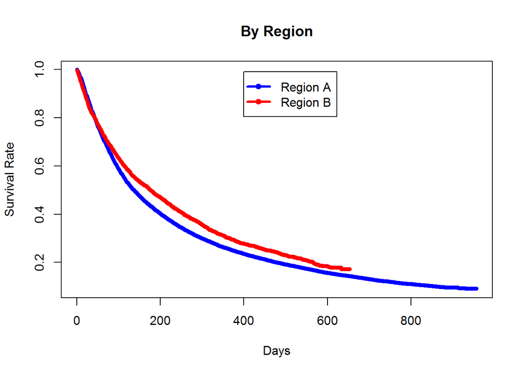

```r
plot(sa_us_km_fit$surv,
     main = 'By Region',
     ylab = "Survival Rate", xlab = "Days",
     lty = 2, pch = 20, col = "blue")
points(sa_canada_km_fit$surv, col = "red",lty = 2, pch = 20)
legend(400, 0.99, legend = c('Region A','Region B'),
       col = c("blue","red"),
       lwd = c(3,3), pch = 20)
```

## Part 5: Cox Proportional Hazard Regression Model

```r
#Create binary assessment score features
sa_data$assess_0_30 <- ifelse(sa_data$overall_percentile < 30, 1,0)
sa_data$assess_30_70 <- ifelse(sa_data$overall_percentile >= 30 & sa_data$overall_percentile < 70, 1,0)
sa_data$assess_70_100 <- ifelse(sa_data$overall_percentile >= 70, 1,0)
```

```r
#Binarize 'job applied for' feature
sa_data$sa_app <- ifelse(sa_data$new_job_group_application == "Retail Salespersons", 1,0)
sa_data$sl_app <- ifelse(sa_data$new_job_group_application == "First-Line Supervisors of Retail Sales Workers", 1,0)
```

```r
#Initializing time availability binary features
sa_data$time_slots_available <- 0
sa_data$weekends_only <- NA
sa_data$weekdays_only <- NA
sa_data$both <- NA

#Populating the features with values
for (i in 1:nrow(sa_data)){
  temp <- as.character(sa_data$times_available[i])
  sa_data$time_slots_available[i] <- length(unlist(strsplit(temp,";")))
  sa_data$weekends_only[i] <- ifelse(grepl("(Sat|Sun)",temp) == TRUE & grepl("(Mon|Tues|Wed|Thurs|Fri)",temp) == FALSE,1,0)
  sa_data$weekdays_only[i] <- ifelse(grepl("(Sat|Sun)",temp) == FALSE & grepl("(Mon|Tues|Wed|Thurs|Fri)",temp) == TRUE,1,0)
  sa_data$both[i] <- ifelse(grepl("(Sat|Sun)",temp) == TRUE & grepl("(Mon|Tues|Wed|Thurs|Fri)",temp) == TRUE,1,0)
}

#Fill in NA if no time slots selected
sa_data$weekends_only[sa_data$time_slots_available == 0] <- NA
sa_data$weekdays_only[sa_data$time_slots_available == 0] <- NA
sa_data$both[sa_data$time_slots_available == 0] <- NA
```

# Computing Cox PH Model

Round 1: Fitting the COX PH model to associate survival hazard with potential predictors

```r
set.seed(22)

#Create the formula
form <- formula(sa_surv ~ assess_0_30 + assess_30_70 + assess_70_100 +
                  weekends_only + weekdays_only + both +
                  sa_app + sl_app + rehire +
                high_school + associates + bachelor + masters_plus)
```

```r
#Fit Cox Model
sa_cox <- coxph(form, data = sa_data,x = TRUE)
summary(sa_cox)
```

```
## Call:
## coxph(formula = form, data = sa_data, x = TRUE)
##
##   n= 52814, number of events= 37727
##    (680 observations deleted due to missingness)
##
##                   coef exp(coef) se(coef)      z Pr(>|z|)
## assess_0_30   -0.14716   0.86315  0.01709 -8.611  < 2e-16 ***
## assess_30_70  -0.08658   0.91706  0.01112 -7.783 7.11e-15 ***
## assess_70_100       NA        NA  0.00000     NA       NA
## weekends_only  0.22870   1.25697  0.03755  6.090 1.13e-09 ***
## weekdays_only -0.01209   0.98798  0.02603 -0.465  0.64227
## both                NA        NA  0.00000     NA       NA
## sa_app        -0.08464   0.91884  0.02950 -2.869  0.00412 **
## sl_app              NA        NA  0.00000     NA       NA
## rehire        -0.18250   0.83318  0.01980 -9.216  < 2e-16 ***
## high_school    0.23110   1.25998  0.04156  5.560 2.69e-08 ***
## associates     0.17688   1.19349  0.04308  4.106 4.03e-05 ***
## bachelor       0.10737   1.11335  0.04265  2.518  0.01182 *
## masters_plus   0.09151   1.09582  0.04758  1.923  0.05443 .
## ---
## Signif. codes:  0 '***' 0.001 '**' 0.01 '*' 0.05 '.' 0.1 ' ' 1
##
##               exp(coef) exp(-coef) lower .95 upper .95
## assess_0_30      0.8632     1.1585    0.8347    0.8926
## assess_30_70     0.9171     1.0904    0.8973    0.9373
## assess_70_100        NA         NA        NA        NA
## weekends_only    1.2570     0.7956    1.1678    1.3530
## weekdays_only    0.9880     1.0122    0.9388    1.0397
## both                 NA         NA        NA        NA
## sa_app           0.9188     1.0883    0.8672    0.9735
## sl_app               NA         NA        NA        NA
## rehire           0.8332     1.2002    0.8015    0.8662
## high_school      1.2600     0.7937    1.1614    1.3669
## associates       1.1935     0.8379    1.0968    1.2987
## bachelor         1.1133     0.8982    1.0241    1.2104
## masters_plus     1.0958     0.9126    0.9983    1.2029
##
## Concordance= 0.532  (se = 0.002 )
## Rsquare= 0.007   (max possible= 1 )
## Likelihood ratio test= 355  on 10 df,   p=0
## Wald test            = 347.9  on 10 df,   p=0
## Score (logrank) test = 348.4  on 10 df,   p=0
```

Plot survival estimates based on the model:

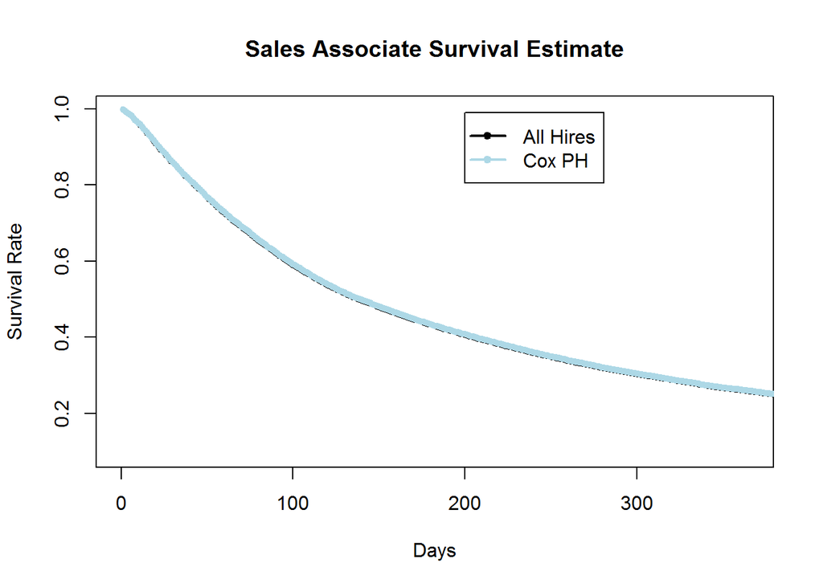

```r
sa_cox_fit <- survfit(sa_cox)
plot(sa_km_fit$surv,
     main = 'Sales Associate Survival Estimate', ylab = "Survival Rate", xlab = "Days",
     xlim = c(0,365), lty = 2, pch = 20)
points(sa_cox_fit$surv, col = "lightblue",lty = 2, pch = 20)
legend(200, 0.99, legend = c('All Hires','Cox PH'),
       col = c("black","lightblue"), pch = c(20,20),
       lwd = c(2,2))
```

Round 2: Kept only statistically significant features at 5% significance value (dropped ‘weekdays_only’, ‘both’, ‘assess_70_100’,‘sl_app’ and ‘masters_plus’)

```r
form <- formula(sa_surv ~ assess_0_30 + assess_30_70 +
                  weekends_only +
                  sa_app + rehire +
                  high_school + associates + bachelor)

#Fit Cox Model
sa_cox <- coxph(form, data = sa_data,x = TRUE)
summary(sa_cox)
```

```
## Call:
## coxph(formula = form, data = sa_data, x = TRUE)
##
##   n= 52814, number of events= 37727
##    (680 observations deleted due to missingness)
##
##                   coef exp(coef) se(coef)      z Pr(>|z|)
## assess_0_30   -0.14841   0.86207  0.01707 -8.693  < 2e-16 ***
## assess_30_70  -0.08694   0.91673  0.01112 -7.817 5.44e-15 ***
## weekends_only  0.22964   1.25815  0.03753  6.119 9.44e-10 ***
## sa_app        -0.08505   0.91846  0.02950 -2.883  0.00393 **
## rehire        -0.18328   0.83253  0.01979 -9.260  < 2e-16 ***
## high_school    0.16394   1.17815  0.02185  7.503 6.22e-14 ***
## associates     0.10961   1.11585  0.02460  4.456 8.34e-06 ***
## bachelor       0.04010   1.04092  0.02383  1.683  0.09239 .
## ---
## Signif. codes:  0 '***' 0.001 '**' 0.01 '*' 0.05 '.' 0.1 ' ' 1
##
##               exp(coef) exp(-coef) lower .95 upper .95
## assess_0_30      0.8621     1.1600    0.8337    0.8914
## assess_30_70     0.9167     1.0908    0.8970    0.9369
## weekends_only    1.2581     0.7948    1.1689    1.3542
## sa_app           0.9185     1.0888    0.8669    0.9731
## rehire           0.8325     1.2012    0.8009    0.8655
## high_school      1.1781     0.8488    1.1288    1.2297
## associates       1.1158     0.8962    1.0633    1.1710
## bachelor         1.0409     0.9607    0.9934    1.0907
##
## Concordance= 0.532  (se = 0.002 )
## Rsquare= 0.007   (max possible= 1 )
## Likelihood ratio test= 351  on 8 df,   p=0
## Wald test            = 344.7  on 8 df,   p=0
## Score (logrank) test = 345.1  on 8 df,   p=0
```

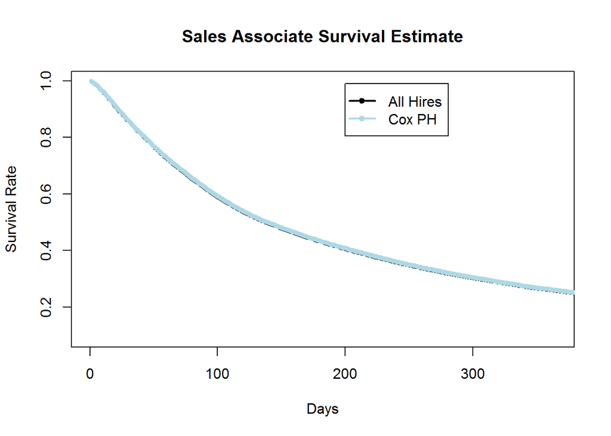

```r
#Plot survival estimates
sa_cox_fit <- survfit(sa_cox)
plot(sa_km_fit$surv,
     main = 'Sales Associate Survival Estimate', ylab = "Survival Rate", xlab = "Days",
     xlim = c(0,365), lty = 2, pch = 20)
points(sa_cox_fit$surv, col = "lightblue",lty = 2, pch = 20)
legend(200, 0.99, legend = c('All Hires','Cox PH'),
       col = c("black","lightblue"), pch = c(20,20),
       lwd = c(2,2))
```

Extracting predicted survival rates

```r
newdata <- subset(sa_data, select = c(applicant_id, assess_0_30,assess_30_70,assess_70_100,
                                      weekends_only,weekdays_only,both,
                                      sa_app,sl_app, rehire, college,
                                    high_school, associates,bachelor, masters_plus))
#Base hazard at time t
bh=basehaz(sa_cox)

#Example specific points in time (days)
times <- c(10,30,90,180,365,730)

#Sample applicant IDs
IDs<-c(14704065,14740260,15014188,15020641,15091641)

#Subset data only for these IDs
Applicants_select= subset(sa_data, sa_data$applicant_id %in% IDs)

#Create empty columsn for the specified points in time
Applicants_select$T_10<-NA
Applicants_select$T_30<-NA
Applicants_select$T_90<-NA
Applicants_select$T_180<-NA
Applicants_select$T_365<-NA
Applicants_select$T_730<-NA


#Formula to calculate Survival at a given point in time for a given person p:
#exp(-bh$hazard[times])^(exp(sum(sa_cox$coefficients*newdata[person,], na.rm = TRUE)))
for (i in 1: length(IDs)){

    Applicants_select$T_10[i]=exp(-bh$hazard[10])^(exp(sum(sa_cox$coefficients*newdata[newdata$applicant_id==IDs[i],][, -(which(names(newdata) %in% "applicant_id"))], na.rm = TRUE)))

    Applicants_select$T_30[i]=exp(-bh$hazard[30])^(exp(sum(sa_cox$coefficients*newdata[newdata$applicant_id==IDs[i],][, -(which(names(newdata) %in% "applicant_id"))], na.rm = TRUE)))

    Applicants_select$T_90[i]=exp(-bh$hazard[90])^(exp(sum(sa_cox$coefficients*newdata[newdata$applicant_id==IDs[i],][, -(which(names(newdata) %in% "applicant_id"))], na.rm = TRUE)))

    Applicants_select$T_180[i]=exp(-bh$hazard[180])^(exp(sum(sa_cox$coefficients*newdata[newdata$applicant_id==IDs[i],][, -(which(names(newdata) %in% "applicant_id"))], na.rm = TRUE)))

    Applicants_select$T_365[i]=exp(-bh$hazard[365])^(exp(sum(sa_cox$coefficients*newdata[newdata$applicant_id==IDs[i],][, -(which(names(newdata) %in% "applicant_id"))], na.rm = TRUE)))

    Applicants_select$T_730[i]=exp(-bh$hazard[730])^(exp(sum(sa_cox$coefficients*newdata[newdata$applicant_id==IDs[i],][, -(which(names(newdata) %in% "applicant_id"))], na.rm = TRUE)))

}

#Saving survival rates at the specified points in time for the randomly selected applicants
#Applicants_select=subset(Applicants_select,select = c("T_10","T_30","T_90","T_180","T_365","T_730"))
#write.csv(Applicants_select, file = "Applicants_select.csv")
```

# Model Diagnostics

```r
#Testing  for the proportional-hazards (PH) assumption
#A p-value less than 0.05 indicates a violation of the proportionality assumption.
test.ph <- cox.zph(sa_cox)
test.ph
```

```
##                    rho   chisq       p
## assess_0_30    0.01265   6.020 0.01415
## assess_30_70   0.00963   3.500 0.06137
## weekends_only -0.00982   3.632 0.05666
## sa_app         0.00327   0.403 0.52551
## rehire         0.04417  73.594 0.00000
## high_school   -0.00501   0.945 0.33098
## associates    -0.01445   7.883 0.00499
## bachelor       0.00570   1.225 0.26834
## GLOBAL              NA 116.232 0.00000
```

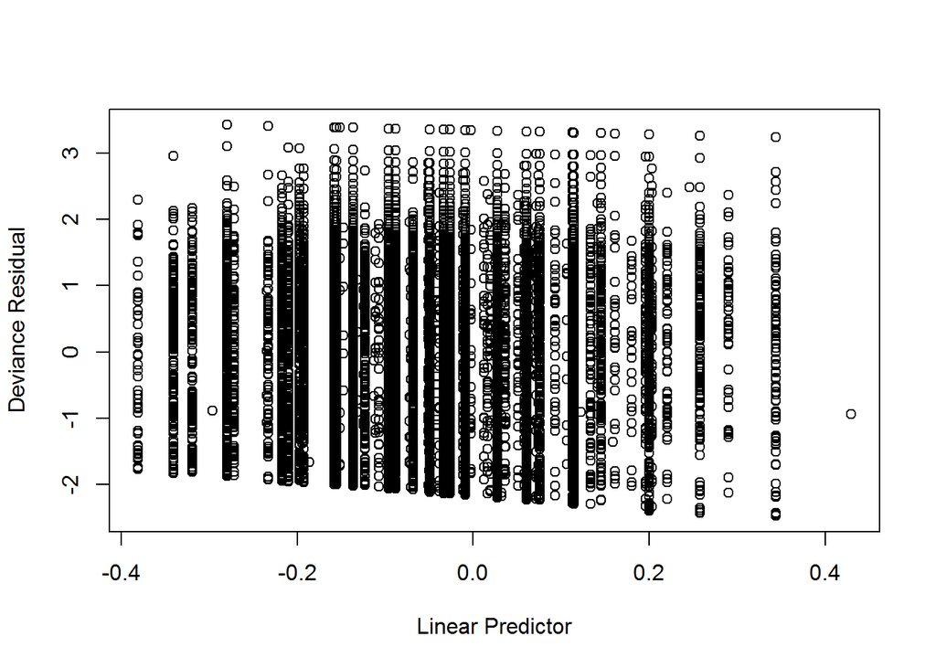

```r
#Testing for influential observations
#ggcoxdiagnostics(sa_cox, type = , linear.predictions = TRUE)
#dfbetas <- residuals(sa_cox, type="dfbetas")
dresids <- residuals( sa_cox, type="deviance" )
lp <- predict(sa_cox, type="lp" )
plot(lp, dresids, xlab="Linear Predictor", ylab="Deviance Residual")
```

```r
########################
```